# Projeto Integrador Ciência de dados - IMIH

Gerson Vasconcelos Neto - Exercício 03

Março de 2018

# Introdução

Vamos estudar com uma amostra do banco de dados do Enade. O Enade, Exame Nacional de Desempenho dos Estudantes, é um dos procedimentos de avaliação do Sistema Nacional de Avaliação da Educação Superior (Sinaes). O teste avalia o rendimento dos alunos dos cursos de graduação, ingressantes e concluintes, em relação aos conteúdos programáticos dos cursos em que estão matriculados. O exame é obrigatório para os alunos selecionados e condição indispensável para a emissão do histórico escolar. Seus resultados poderão produzir dados por instituição de educação superior, categoria administrativa, organização acadêmica, município, estado, região geográfica e Brasil. Assim, serão construídos referenciais que permitam a definição de ações voltadas à melhoria da qualidade dos cursos de graduação por parte de professores, técnicos, dirigentes e autoridades educacionais.

# Exercício com uma amostra do ENADE

**1. Mostre com um comando e usando um gráfico a distribuição das idades dessa amostra de alunos que fizeram ENADE em 2014. Comente o resultado.**

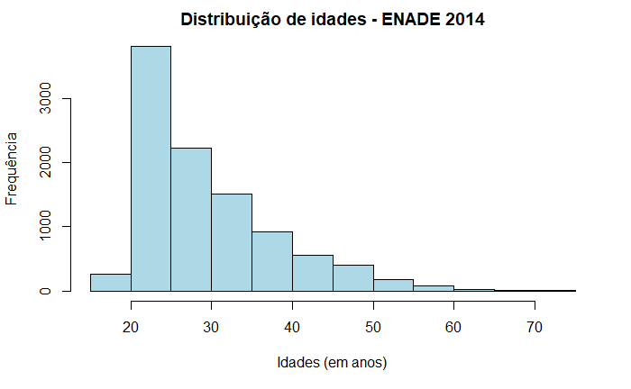

```r
hist(enade14$nu_idade,
     col = "lightblue",
     main = "Distribuição de idades - ENADE 2014",
     xlab = "Idades (em anos)",
     ylab = "Frequência")
```

O resultado gráfico nos mostra que há uma grande concentração dos alunos com uma idade entre 20 e 30 anos realizando a prova do Enade em 2014.

**2.Monte uma tabela exibindo as porcentagens e os valores absolutos das proporções de alunos por COR/RAÇA. O descobrimos sobre isso?**

Teremos 3 jeitos de fazer, sendo o primeiro manual, usando um `data.frame`:

```r
freq_ni <- table(enade14$qe_i2)  # frequências absolutas das respostas do questionário
freq_rel_fi <- prop.table(freq_ni) # tabela de frequências relativas
porcentagem_fi <- 100 * prop.table(freq_ni) # Porcentagem de frequência relativas
# Adicionando vetores de soma total
freq_ni <- c(freq_ni, sum(freq_ni))
freq_rel_fi <- c(freq_rel_fi, sum(freq_rel_fi))
porcentagem_fi <- c(porcentagem_fi, sum(porcentagem_fi))
##
tab_1 <- cbind(freq_ni, freq_rel_fi = round(freq_rel_fi, digits = 2),
               porcentagem_fi = round(porcentagem_fi, digits = 2))  # criando a tabela
# Ajeitando o formato da tabela para data frame e renomeando os labels
tab_1 <- as.data.frame(tab_1)
names(tab_1) <- c("Frequência absoluta", "Frequência relativa",
                     "Percentual (%)")
rownames(tab_1) <- c("Branco(a)", "Negro(a)", "Pardo(a)/mulato(a)",
                     "Amarelo(a) (de origem oriental)", "Indígena ou de origem indígena",
                     "Total")
tab_1
```

|  | Frequência absoluta | Frequência relativa | Percentual (%) |
| --- | --- | --- | --- |
| Branco(a) | 4606 | 0.53 | 52.98 |
| Negro(a) | 893 | 0.10 | 10.27 |
| Pardo(a)/mulato(a) | 2988 | 0.34 | 34.37 |
| Amarelo(a) (de origem oriental) | 129 | 0.01 | 1.48 |
| Indígena ou de origem indígena | 78 | 0.01 | 0.90 |
| Total | 8694 | 1.00 | 100.00 |

o segundo com o pacote `knitr`:

```r
# um segundo jeito de ajeitar a tabela
library(knitr)
rownames(tab_1) <- c("Branco(a)", "Negro(a)", "Pardo(a)/mulato(a)",
                     "Amarelo(a) (de origem oriental)", "Indígena ou de origem indígena",
                     "Total")  # Nomeando as variáveis
kable(tab_1, caption = "Distribuição de Cor/Raça Enade 2014",
      col.names = c("Frequência absoluta", "Frequência relativa",
                     "Percentual (%)"))
```

|  | Frequência absoluta | Frequência relativa | Percentual (%) |
| --- | --- | --- | --- |
| Branco(a) | 4606 | 0.53 | 52.98 |
| Negro(a) | 893 | 0.10 | 10.27 |
| Pardo(a)/mulato(a) | 2988 | 0.34 | 34.37 |
| Amarelo(a) (de origem oriental) | 129 | 0.01 | 1.48 |
| Indígena ou de origem indígena | 78 | 0.01 | 0.90 |
| Total | 8694 | 1.00 | 100.00 |

e o terceiro com o pacote `descr`:

```r
library("descr")
raca <- as.factor(enade14$qe_i2)
levels(raca) <- c("Branco(a)", "Negro(a)", "Pardo(a)/mulato(a)",
                     "Amarelo(a) (de origem oriental)", "Indígena ou de origem indígena")
                     # dando nome às variáveis
freq(raca, plot = F)
```

```
raca
                                Frequência Percentual Perc. Válido
Branco(a)                             4606      46.06      52.9791
Negro(a)                               893       8.93      10.2715
Pardo(a)/mulato(a)                    2988      29.88      34.3685
Amarelo(a) (de origem oriental)        129       1.29       1.4838
Indígena ou de origem indígena          78       0.78       0.8972
NA's                                  1306      13.06
Total                                10000     100.00     100.0000
```

A conclusão que chegamos ao ver essa tabela é que os alunos de cor branca são a maioria na prova do Enade 2014, e por consequência também nas universidades, maior que até mesmo nos negros e pardos juntos.

**3. Apresente a proporção de alunos casados e solteiros. Atenção, queremos apenas CASADOS e SOLTEIROS. Exclua de sua análise os alunos que tiverem outro tipo de estado civil.**

```
est_civ1[est_civ1 == "Solteiro(a)" | est_civ1 == "Casado(a)"]
            Frequência Percentual Perc. Válido
Casado(a)         2486      26.79        31.18
Solteiro(a)       5487      59.13        68.82
NA's              1306      14.07
Total             9279     100.00       100.00
```

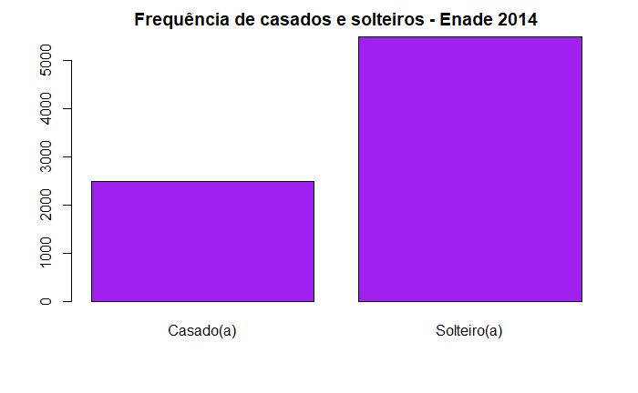

```r
library(descr)
est_civ <- as.factor(enade14$qe_i1)
levels(est_civ) <- c("Solteiro(a)", "Casado(a)", "c", "d", "e") # transformando os nomes
est_civ1 <- as.character(est_civ) # volto para character pois se rodasse o freq como factor
                                  # iria dar errado
freq(est_civ1[est_civ1 == "Solteiro(a)" | est_civ1 == "Casado(a)"], col = "purple",
     main = "Frequência de casados e solteiros - Enade 2014")  #subsetting os "solteiros" e "casados"
```

**4. Apresente estatísticas descritivas sobre a nota geral dos alunos no Enade. Apresente também a informação em um gráfico. Qual é o gráfico mais adequado para a visualização desta variável? Por quê? Comente sobre a nota geral. Os alunos parecem ter, no geral, um bom desempenho ou um mal desempenho?**

O gráfico mais adequado para a utilização nesse caso será um boxplot, pois nos dá uma noção gráfica da distribuição, dispersão e assimetria através da visualização dos quartis. Abaixo segue algumas estatísticas descritivas:

```r
summary(enade14$nt_ger)
```

```
   Min. 1st Qu.  Median    Mean 3rd Qu.    Max.    NA's
    0.0   292.0   414.0   399.6   528.0   943.0    1724
```

e o gráfico previamente referido:

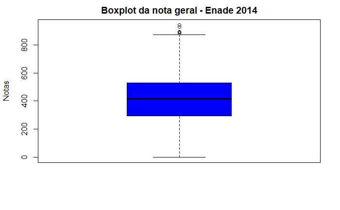

```r
boxplot(enade14$nt_ger, col = "blue",
        main = "Boxplot da nota geral - Enade 2014",
        ylab = "Notas")
```

Através da análise do gráfico e das estatísticas descritivas podemos afirmar que no geral os alunos do Enade 2014 tiveram um desempenho médio muito insatisfatório visto que a média geral da nota dos alunos não chega nem a 50% de acerto do total da prova.

**5. Crie uma variável binária chamada PUBLICA. Nessa variável, você deve marcar 1 se a universidade em que o aluno estudou foi pública e 0 se foi privada. ATENÇÃO: existe uma variável com a categoria administrativa da IES mas ela possui várias subclassificações. É preciso que você crie outra variável com as categorias corretas.**

```r
PUBLICA1 <- as.factor(enade14$co_catad)
levels(PUBLICA1) <- c(1, 1, 0, 0, 1, 1, 1, 0, 0, 0, 0, 0, 0)
pb <- table(PUBLICA1)
prop.table(pb)*100
```

```
PUBLICA1
    1     0
38.61 61.39
```

outro jeito para fazer:

```r
PUBLICA2 <- ifelse(enade14$co_catad == 93 |
                     enade14$co_catad == 116 |
                     enade14$co_catad == 10001 |
                     enade14$co_catad == 10002 |
                     enade14$co_catad == 10003, 1, 0)
```

**6. Mostre a distribuição da renda para os alunos do ENADE 2014. Mostre também a distribuição de renda apenas para os alunos das escolas públicas e das escolas privadas.**

Distribuição de renda de todos os alunos:

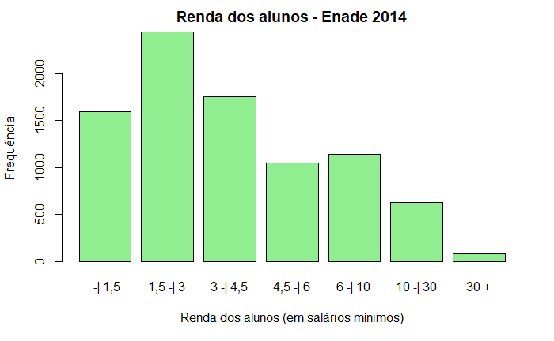

```r
renda <- as.factor(enade14$qe_i8)
levels(renda) <- c(" -| 1,5", "1,5 -| 3", "3 -| 4,5", "4,5 -| 6", "6 -| 10", "10 -| 30", "30 +")
barplot(table(renda), col ="lightgreen",
        main = "Renda dos alunos - Enade 2014",
        xlab = "Renda dos alunos (em salários mínimos)",
        ylab = "Frequência")   # plotando gráfico de frequência de variáveis categóricas
```

Distribuição de renda para alunos de escolas públicas:

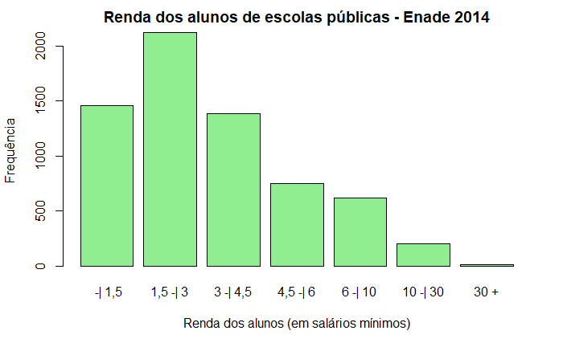

```r
e_pub <- ifelse(enade14$qe_i17 == "a" | enade14$qe_i17 == "d", 1 , 0)
# considerei escola pública como os alunos que cursaram todo ou a maior parte na escola pública
# freq(enade14$qe_i8[e_pub == 1],
#     col = "black",
#     main = " Distribuição de renda para aluno de escolas públicas - Enade 2014")
# também poderia ser feito desta maneira mas não ficaria com os labels certinho
barplot(table(renda[e_pub == 1]), col ="lightgreen",
        main = "Renda dos alunos de escolas públicas - Enade 2014",
        xlab = "Renda dos alunos (em salários mínimos)",
        ylab = "Frequência")
```

Distribuição de renda para alunos de escolas privadas:

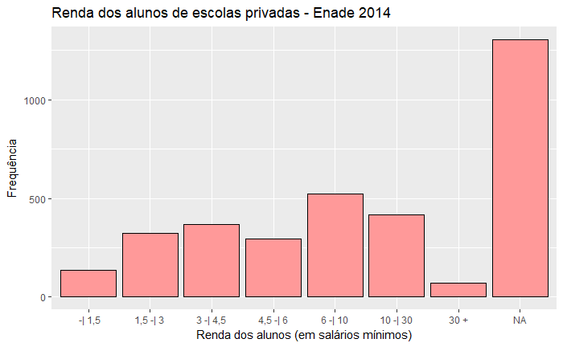

```r
e_priv <- ifelse(enade14$qe_i17 == "b" | enade14$qe_i17 == "e", 1, 0)
# considerei alunos de escolas privadas como quem cursou toda ou a maior parte em escolas privadas
#barplot(table(renda[e_priv == 1]), col ="lightgreen",
#        main = "Renda dos alunos de escolas privadas - Enade 2014",
#        xlab = "Renda dos alunos (em salários mínimos)",
#        ylab = "Frequência")
# ou usando o ggplot2
## ps.: Neylson, não consegui tirar os NAs, tentei diversas formas e dava erro! ajuda ae!
## Error: Aesthetics must be either length 1 or the same as the data (2130): x
## esse é o que tava dando sempre
library(tidyverse)
dd <- as.data.frame(renda[e_priv == 1]) ## transformando em data frame porque é o formato do ggplot2
# dd2 <- na.omit(dd)
ggplot(data = dd, aes(x =renda[e_priv == 1]))+
  geom_bar(fill="#FF9999", colour="black")+
  labs(title = "Renda dos alunos de escolas privadas - Enade 2014",
       x = "Renda dos alunos (em salários mínimos)",
       y= "Frequência")
```

**7. Mostre agora a nota geral dos alunos das faculdades públicas e dos alunos das faculdades privadas. O que você acha desses dados?**

Média da nota geral dos alunos de faculdades públicas:

```r
nt_pub <- enade14$nt_ger[PUBLICA2 == 1]
mean(nt_pub, na.rm = T)
```

```
[1] 411.9
```

Média da nota geral dos alunos de faculdades privadas:

```r
nt_priv <- enade14$nt_ger[PUBLICA1 == 0]
mean(nt_priv, na.rm = T)
```

```
[1] 391.9547
```

Os dados retratam a realidade das nossas instituições de ensino superior, com as instituições públicas, que são geralmente mais conceituadas, com uma média maior que as privadas.

**BÔNUS 1: Existe um teste estatístico para verificar se a média da nota geral desta amostra dos alunos que fizeram ENADE pode ser inferida para toda a população? Faça o teste e apresente os resultados. Qual é o intervalo de confiança do teste?**

Primeiro vamos ver qual a distribuição da amostra:

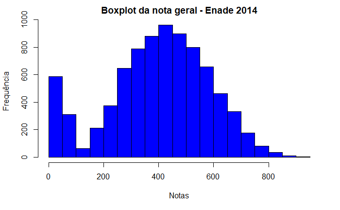

```r
hist(enade14$nt_ger, col = "blue",
        main = "Boxplot da nota geral - Enade 2014",
        xlab = "Notas",
        ylab = "Frequência")
```

```r
t.test(enade14$nt_ger)
```

```
    One Sample t-test

data:  enade14$nt_ger
t = 197.26, df = 8275, p-value < 2.2e-16
alternative hypothesis: true mean is not equal to 0
95 percent confidence interval:
 395.6473 403.5898
sample estimates:
mean of x
 399.6185
```

**BÔNUS 2: Existe um teste estatístico para verificar se a diferença entre as notas dos alunos das universidades públicas e dos alunos das universidades privadas é estatisticamente significante? Faça o teste e apresente os resultados.**

```r
## não consegui fazer pois ele diz que os comprimentos das variáveis são diferentes.
## Mas a quantidade de pessoas que fizeram em instituções públicas e privadas diferem.
## O que fazer ? dá aquela luz aee mestre Neylson!!
t.test(nt_pub ~ nt_priv)
```

```
Error in model.frame.default(formula = nt_pub ~ nt_priv) :
  comprimentos das variáveis diferem (encontradas em 'nt_priv')
```